# ACF, PACF, and ARMA models

2024-01-07

```r
# Import library
library(fpp3)
```

## Q1) Draw Time series plot, ACF and PACF for the data.

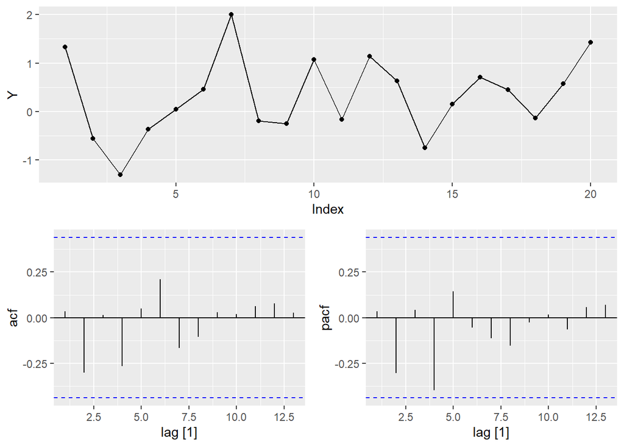

```r
y = c(1.33, -0.56, -1.31, -0.37, 0.05, 0.46, 2.00, -0.19,
    -0.25, 1.07, -0.17, 1.14, 0.63, -0.75, 0.15, 0.71, 0.45,
    -0.14, 0.57, 1.43)


# Create time series
Y = tsibble(
    Y = y,
    Index = seq_along(y),
    index = Index)


# Plot time series, ACF, and PACF
Y %>% gg_tsdisplay(Y, plot_type = "partial")
```

## Q2) Find moment estimates of sigma^2 and theta for MA(1) model

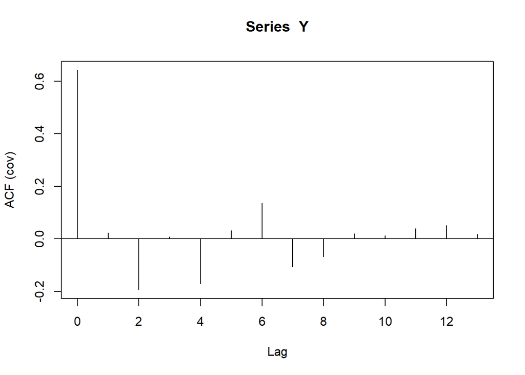

```r
# Find sample autocovariance and sample autocorrelation

C1 <- acf(Y, type = "covariance")$acf[2]
```

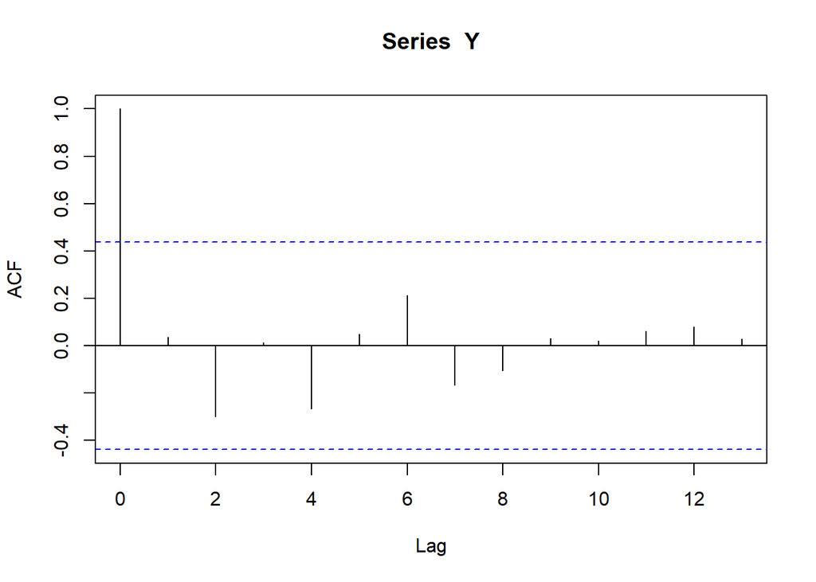

```r
r1 <- acf(Y)$acf[2]
```

```r
theta_hat <- c(1-sqrt(1-4*r1^2), 1+sqrt(1-4*r1^2))/(2*r1)

sigma_squared <- C1/0.03628507
```

Since 27.5594216 >1, we reject since we need a stationary solution.

Thus, the theta_hat is 0.03628

Hence, answer is: sigma^2 = 0.6414742, theta_hat = 0.03628

## Q3) Find least squares estimates of phi1,phi2, sigma^2 of an AR(2) model. Find 95% CI for each of phi1 and phi2.

```r
# Create data frame for fitting AR(2) model using lm() function

df <- data.frame(
    y_regressand <- y[3:20],
    y_lag1 <- y[2:19],
    y_lag2 <- y[1:18]
)

# Regress y_regressand on y_lag1 and y_lag2, omit constant

fit.ls <- lm(y_regressand ~ y_lag1 + y_lag2 -1, data = df)
summary(fit.ls)
```

```
##
## Call:
## lm(formula = y_regressand ~ y_lag1 + y_lag2 - 1, data = df)
##
## Residuals:
##     Min      1Q  Median      3Q     Max
## -0.8815 -0.1787  0.3201  0.6543  1.9029
##
## Coefficients:
##        Estimate Std. Error t value Pr(>|t|)
## y_lag1   0.2354     0.2573   0.915    0.374
## y_lag2  -0.2230     0.2419  -0.922    0.370
##
## Residual standard error: 0.8507 on 16 degrees of freedom
## Multiple R-squared:  0.08955,    Adjusted R-squared:  -0.02425
## F-statistic: 0.7869 on 2 and 16 DF,  p-value: 0.4721
```

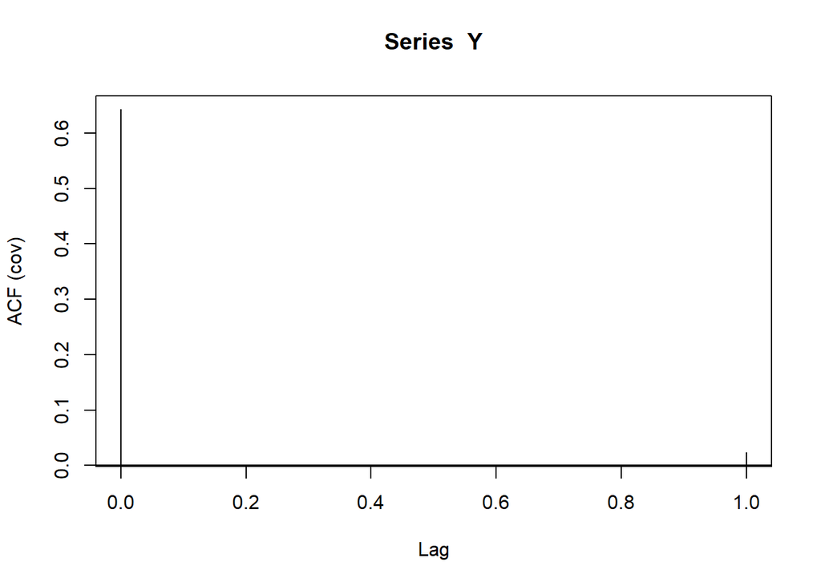

```r
# LSE of sigma^2
sigma_squared.ls <- (sum(resid(fit.ls)^2))/16

# Finding Confidence Interval for phi1 and phi2
# Create Gamma Matrix
p <- acf(Y, 1, type = 'covariance')$acf
```

```r
GAMMA <- matrix(c(p[1],p[2],p[2],p[1]), nrow =2)


# Estimate standard error of phi1 and phi2
GAM.inv <- solve(GAMMA)
var.phi <- (sigma_squared.ls/20) * GAM.inv[1,1]

# Construct 95% CI for phi1 and phi2
cbind(fit.ls$coefficients - 2*sqrt(var.phi), fit.ls$coefficients + 2*sqrt(var.phi))
```

```
##              [,1]      [,2]
## y_lag1 -0.2396240 0.7103563
## y_lag2 -0.6980286 0.2519517
```

Answer: phi1 = 0.2354, phi2 = -0.2230, sigma^2 = 0.7236343

95% CI of phi1: [-0.2396240, 0.7103563], 95% CI of phi2: [-0.6980286, 0.2519517]

## Q4) Find Yule-Walker Estimates of phi1 and phi2 for fitting AR(2) model

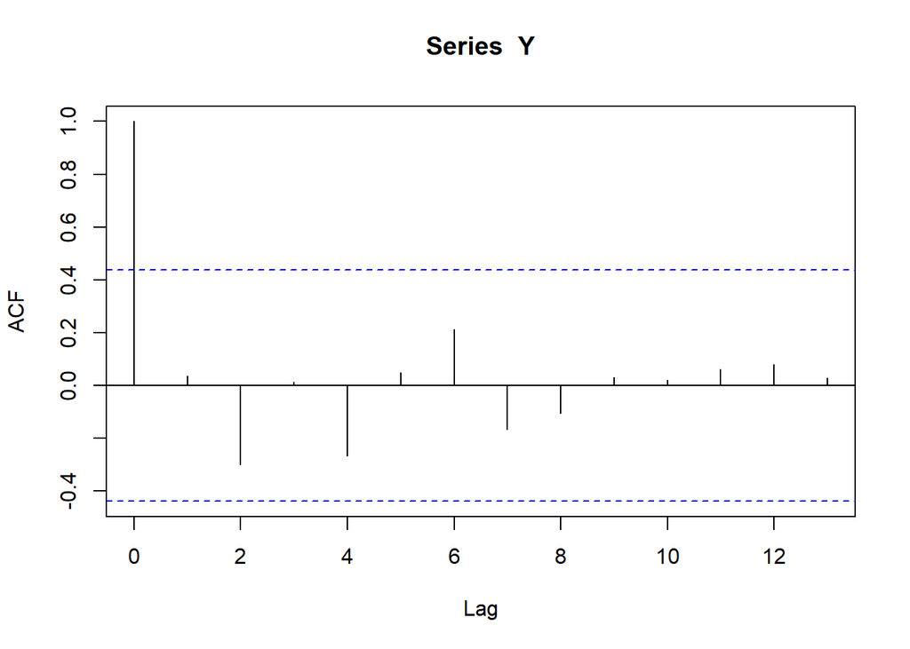

```r
r1 <- acf(Y)$acf[2]
r2 <- acf(Y)$acf[3]
```

```r
# Yule-Walker matrix
YW <- matrix(c(1,r1,r1,1),2)
rho <- c(r1,r2)

# Solve for phi
phi.yw <- solve(YW,rho)
```

Answer: phi1 = 0.04718125, phi2 = -0.30200553

## Q5) Find CSS estimates of phi, theta, and sigma^2 for fitting ARIMA(1,1) model

```r
# Create function get.z
get.z <- function(arg) {
    phi = arg[1]
    theta = arg[2]
    z = rep(NA,length((y)))
    z[1] = y[1]
    for (j in seq.int(2,length(y))) {
        z[j] = y[j] - phi*y[j-1] - theta*z[j-1]
    }
    return(sum(z^2))
}

# Optimize get.z
results <- optim(c(0.1,0.1),get.z)

# Find sigma2
sigma_squared.css <- results$value/(length(y)-1)
```

Answer: phi = -0.5108904, theta = 0.8439972, sigma^2 = 0.6810138

## Q6) Find the MLE of phi, theta, sigma^2 of ARMA(1,1) model, w/o constant

```r
fit.MLE <- arima(y, order=c(1,0,1), include.mean = FALSE)

# call loglikelihood
fit.MLE$loglik
```

```
## [1] -23.08444
```

Answer: phi = -0.3883, theta = 1, max value of loglikelihood = -23.08444

## Q7) Among AR(p), p=1,2,3,4,5, which model is best in terms of FPE?

```r
FPE<-rep(0,5)

# Fit five AR models from p=1 to p=5, omit constant
for (p in 1:5) {
    fit.fpe<-arima(y,order=c(p,0,0),include.mean=F)
    sigma2<-fit.fpe$sigma2
    FPE[p]<-sigma2*(20+p)/(20-p)
}

bestmodel <- (1:5)[min(FPE)==FPE]
```

Answer: AR(1) is the best model based on FPE. FPE(AR(1)) = 0.8041636

## Q8) Among MA(q), q=1,2,3,4,5, which model is best in terms of AICC?

```r
# fit various MA() models, omit constants

fit.aicc <- Y %>% model(
    arima001 = ARIMA(Y ~ 0 + pdq(0,0,1)),
    arima002 = ARIMA(Y ~ 0 + pdq(0,0,2)),
    arima003 = ARIMA(Y ~ 0 + pdq(0,0,3)),
    arima004 = ARIMA(Y ~ 0 + pdq(0,0,4)),
    arima005 = ARIMA(Y ~ 0 + pdq(0,0,5)),
    )

#Show AIC
glance(fit.aicc) %>% select(AICc)
```

```
## # A tibble: 5 × 1
##    AICc
##   <dbl>
## 1  53.4
## 2  53.2
## 3  56.3
## 4  59.4
## 5  63.6
```

Answer: The model of order 2 has the smallest AICc. Thus, MA(2) is the best model based on AICc

## Q9) Fit MA(1) model Find Ljung_box test statistic Q(10). State H0 and H1, and then draw conclusion.

```r
# Fit MA(1), exclude constant
fit.lj <- Y %>% model(
    arima001 <- ARIMA(Y ~ 0 + pdq(0,0,1))
    )

# Extract residuals
fit.lj %>% augment() %>% select(.innov) -> ma_res
ma_res <- ma_res$.innov

# Conduct ljung_box test statistic for h=10

ljung_box(ma_res, lag = 10)
```

```
##    lb_stat  lb_pvalue
## 11.7302485  0.3035156
```

```r
qchisq(0.95,9)
```

```
## [1] 16.91898
```

Answer: H0: The series of residuals exhibit no autocorrelation for lag of 10.

H1: Some autocorrelation coefficient p(k) for k=1,2,…,h are non-zero.

Since test statistic is 11.7302485 and qchisq value for 95% percentile is 16.91898, we do not reject the null hypothesis. Thus, we can carefully speculate that the model is a good fit.

## Q10) Which model would I fit?

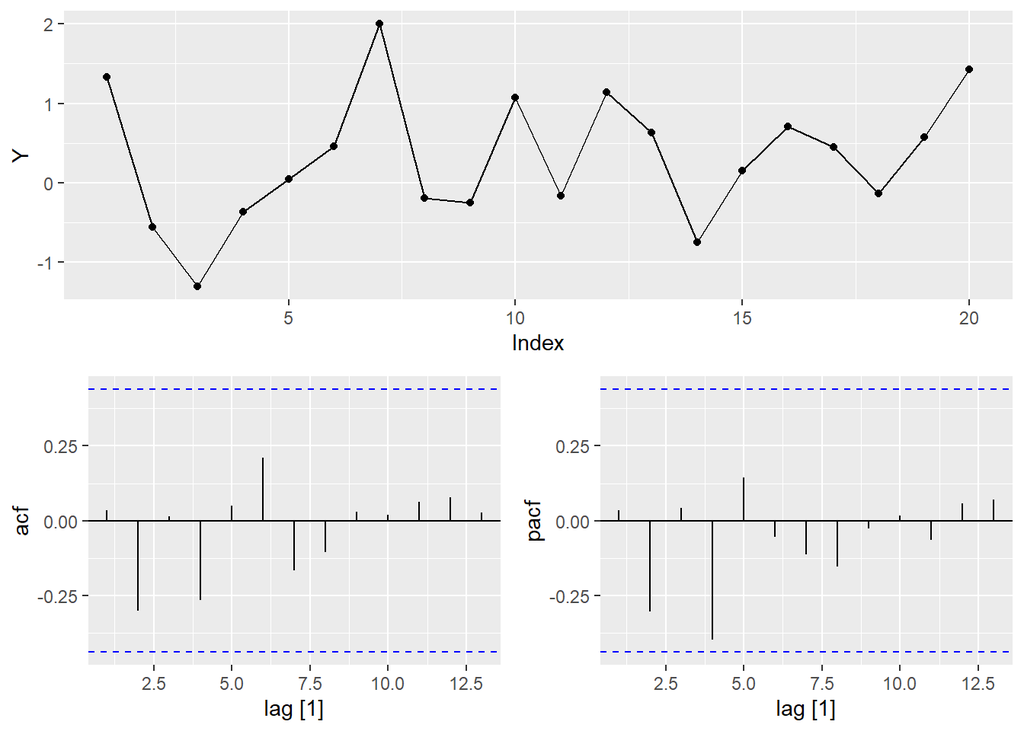

```r
# Check ACF and PACF
Y %>% gg_tsdisplay(Y, plot_type = 'partial')
```

It is Hard to know which model to use from visal inspection.

Thus, we use brute force to iterate all ARIMA(p,0,q) models, calculating the IC values for each model.

Set p,q = 0,1,2,3,4,5. Total of 6*6 = 36 iterations

```r
# Build function to calculate IC values
IC_values=function(x,order.vec){
    p=order.vec[1]
    q=order.vec[2]
    n=length(x)
    fit.q10=arima(x,order=c(order.vec[1],0,order.vec[2]),include.mean=F)
    sigsq=fit.q10$sigma2
    FPE=sigsq*(n+p)/(n-p)
    AIC=fit.q10$aic
    BIC=(n-p-q)*log(n*sigsq/(n-p-1))+n*(1+log(sqrt(2*pi)))+(p+q)*log((sum(x^2)-n*sigsq)/(p+q))
    return(c(AIC,BIC,FPE))
}

# Create empty vectors to populate
AR<-rep(0,35)
MA<-rep(0,35)
AIC<-rep(0,35)
BIC<-rep(0,35)
FPE<-rep(0,35)

# Create dataframe that lists orders of ARMA models along with IC scores
finaldf<-data.frame(AR, MA, AIC, BIC, FPE)

# Populate dataframe by iterating over 36 models
i<-1

for (p in 0:5) {
    for (q in 0:5) {
        finaldf[i,]<-c(p,q,IC_values(y,c(p,q)))
        i<-i+1
    }
}

# Remove NA values

finaldf<- drop_na(finaldf)

# Best model based on AIC

finaldf[finaldf$AIC == min(finaldf$AIC),]
```

```
##   AR MA      AIC      BIC       FPE
## 2  0  2 51.70218 28.74301 0.5061039
```

```r
# Best model based on BIC

finaldf[finaldf$BIC == min(finaldf$BIC),]
```

```
##    AR MA      AIC      BIC       FPE
## 10  1  4 55.14142 26.81671 0.4013773
```

```r
# Best model based on FPE

finaldf[finaldf$FPE == min(finaldf$FPE),]
```

```
##    AR MA      AIC      BIC       FPE
## 16  2  4 56.41585 26.86246 0.3970868
```

Answer: FPE: ARMA(2,4), AIC: ARMA(0,2), BIC: ARMA(1,4)

Add-in:: Judging from the acf and pacf diagrams, we see lack of autocorrelation to actually suggest appropriate models beside an iid model.